# Data621-Final Project

Joseph Elikishvili

May 23, 2018

## Data Exploration and transformation.

We will get started by loading the 2 csv files, we will need to combine them into a single data frame. We will go ahead and that below and preview the data.

```
##   X    DATE2 start.station.id n HPCP AWND TMAX TMIN WDF2 WDF5 WSF2 WSF5
## 1 1 20130601               72 1   NA  3.8   90   73  250  260 12.1 19.9
## 2 2 20130601               79 3   NA  3.8   90   73  250  260 12.1 19.9
## 3 3 20130601              143 1   NA  3.8   90   73  250  260 12.1 19.9
## 4 4 20130601              146 1   NA  3.8   90   73  250  260 12.1 19.9
## 5 5 20130601              151 1   NA  3.8   90   73  250  260 12.1 19.9
## 6 6 20130601               83 1   NA  3.8   90   73  250  260 12.1 19.9
##   TMID  HOUR
## 1 81.5 00:00
## 2 81.5 00:00
## 3 81.5 00:00
## 4 81.5 00:00
## 5 81.5 00:00
## 6 81.5 00:00
```

It appears we have X predictor that is just an index, we will remove it and proceed. Lets examine the dimension of the data-set

```
## [1] 432409     13
```

It appears we have over 432000 records and 13 variables. This gives us enough data to build our models.

Next we will take a look at HCPC variable which represents an hourly precipitation, it contains a lot of N/A variables which represent the fact that there was none, so we will go ahead and replace all NA records with 0 for that variable.

Next we will examine the data set and review if we have any additional missing data.

```
##            DATE2 start.station.id                n             HPCP
##                1                1                1                0
##             AWND             TMAX             TMIN             WDF2
##                1                1                1                1
##             WDF5             WSF2             WSF5             TMID
##                1                1                1                1
##             HOUR
##                1
```

It appears that the last row has some misting data, so we will go ahead and remove the last row.

```
##           DATE2 start.station.id  n HPCP AWND TMAX TMIN WDF2 WDF5 WSF2
## 432404 20131231              531  2    0 5.82   32   21  290  280   17
## 432405 20131231              538  1    0 5.82   32   21  290  280   17
## 432406 20131231              539  2    0 5.82   32   21  290  280   17
## 432407 20131231              545  2    0 5.82   32   21  290  280   17
## 432408 20131231             2003  1    0 5.82   32   21  290  280   17
## 432409       NA               NA NA    0   NA   NA   NA   NA   NA   NA
##        WSF5 TMID  HOUR
## 432404   28 26.5 23:00
## 432405   28 26.5 23:00
## 432406   28 26.5 23:00
## 432407   28 26.5 23:00
## 432408   28 26.5 23:00
## 432409   NA   NA  <NA>
```

Lets visually examine Missing values by using Amelia library and then confirm by manual output

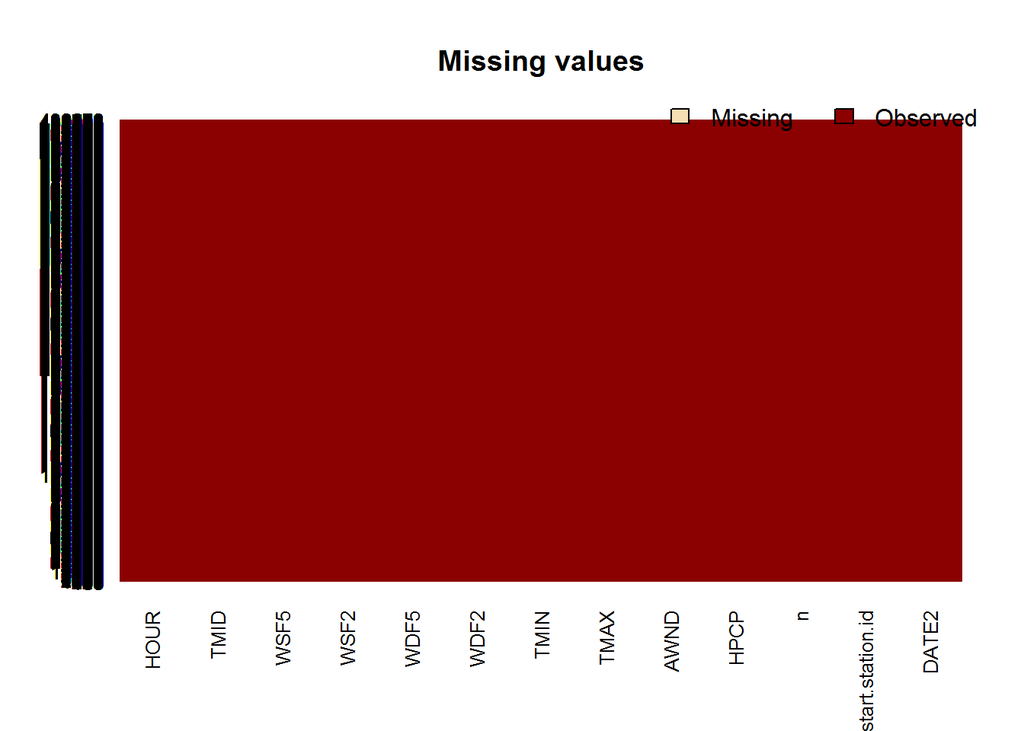

```
##            DATE2 start.station.id                n             HPCP
##                0                0                0                0
##             AWND             TMAX             TMIN             WDF2
##                0                0                0                0
##             WDF5             WSF2             WSF5             TMID
##                0                0                0                0
##             HOUR
##                0
```

It appears we do not have any more missing values and we are ready to proceed.

Next we will check datatype of each of the predictor variables

```
## 'data.frame':    432408 obs. of  13 variables:
##  $ DATE2           : int  20130601 20130601 20130601 20130601 20130601 20130601 20130601 20130601 20130601 20130601 ...
##  $ start.station.id: int  72 79 143 146 151 83 217 223 229 157 ...
##  $ n               : int  1 3 1 1 1 1 2 2 1 2 ...
##  $ HPCP            : num  0 0 0 0 0 0 0 0 0 0 ...
##  $ AWND            : num  3.8 3.8 3.8 3.8 3.8 3.8 3.8 3.8 3.8 3.8 ...
##  $ TMAX            : int  90 90 90 90 90 90 90 90 90 90 ...
##  $ TMIN            : int  73 73 73 73 73 73 73 73 73 73 ...
##  $ WDF2            : int  250 250 250 250 250 250 250 250 250 250 ...
##  $ WDF5            : int  260 260 260 260 260 260 260 260 260 260 ...
##  $ WSF2            : num  12.1 12.1 12.1 12.1 12.1 12.1 12.1 12.1 12.1 12.1 ...
##  $ WSF5            : num  19.9 19.9 19.9 19.9 19.9 19.9 19.9 19.9 19.9 19.9 ...
##  $ TMID            : num  81.5 81.5 81.5 81.5 81.5 81.5 81.5 81.5 81.5 81.5 ...
##  $ HOUR            : Factor w/ 24 levels "00:00","01:00",..: 1 1 1 1 1 1 1 1 1 1 ...
```

We have all predictors as int or num which is good and we can go ahead and leave them as such, The only predictor that is using factor is HOUR, so we will go ahead and convert Hour from strings to numbers 1-24, 1 representing 00:00 and 24 representing 23:00

## Data Visualisation

Next we will review our predictors and analyze various metrics such as SD and range to better understand the data

|  | vars | n | mean | sd | median | trimmed | mad | min | max | range | skew | kurtosis | se |
| --- | --- | --- | --- | --- | --- | --- | --- | --- | --- | --- | --- | --- | --- |
| DATE2 | 1 | 432408 | 20130910.51 | 234.34 | 20130915.00 | 20130909.15 | 429.95 | 20130601.00 | 20131231.00 | 630.00 | 0.03 | -1.36 | 0.36 |
| start.station.id | 2 | 432408 | 447.17 | 379.27 | 390.00 | 387.01 | 131.95 | 72.00 | 3020.00 | 2948.00 | 4.16 | 18.65 | 0.58 |
| n | 3 | 432408 | 4.75 | 5.11 | 3.00 | 3.74 | 2.97 | 1.00 | 108.00 | 107.00 | 3.08 | 17.79 | 0.01 |
| HPCP | 4 | 432408 | 0.00 | 0.04 | 0.00 | 0.00 | 0.00 | 0.00 | 0.94 | 0.94 | 17.76 | 388.94 | 0.00 |
| AWND | 5 | 432408 | 4.62 | 1.58 | 4.47 | 4.55 | 1.65 | 0.89 | 10.07 | 9.18 | 0.45 | 0.29 | 0.00 |
| TMAX | 6 | 432408 | 68.66 | 17.54 | 73.00 | 70.43 | 13.34 | 30.00 | 96.00 | 66.00 | -0.85 | -0.46 | 0.03 |
| TMIN | 7 | 432408 | 53.59 | 15.60 | 57.00 | 54.77 | 13.34 | 19.00 | 77.00 | 58.00 | -0.63 | -0.68 | 0.02 |
| WDF2 | 8 | 432408 | 203.23 | 95.23 | 250.00 | 209.86 | 59.30 | 10.00 | 360.00 | 350.00 | -0.70 | -0.94 | 0.14 |
| WDF5 | 9 | 432408 | 198.56 | 95.34 | 240.00 | 206.09 | 74.13 | 10.00 | 350.00 | 340.00 | -0.70 | -0.93 | 0.14 |
| WSF2 | 10 | 432408 | 12.99 | 3.09 | 12.10 | 12.88 | 2.97 | 6.90 | 21.90 | 15.00 | 0.38 | 0.11 | 0.00 |
| WSF5 | 11 | 432408 | 21.04 | 5.20 | 21.00 | 21.03 | 5.93 | 10.10 | 35.10 | 25.00 | 0.08 | -0.63 | 0.01 |
| TMID | 12 | 432408 | 61.13 | 16.44 | 65.00 | 62.62 | 13.34 | 25.00 | 86.50 | 61.50 | -0.75 | -0.58 | 0.03 |
| HOUR | 13 | 432408 | 14.41 | 5.88 | 15.00 | 14.70 | 5.93 | 1.00 | 24.00 | 23.00 | -0.35 | -0.59 | 0.01 |

We will go ahead and review box-plots and histograms to better understand the shape of the data we are dealing with

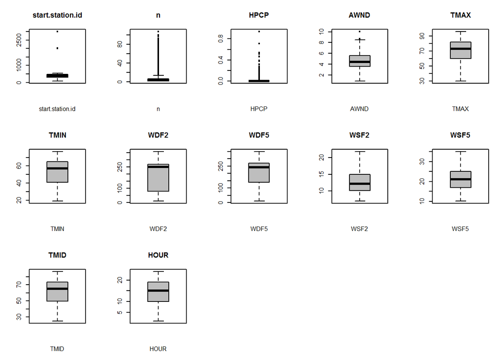

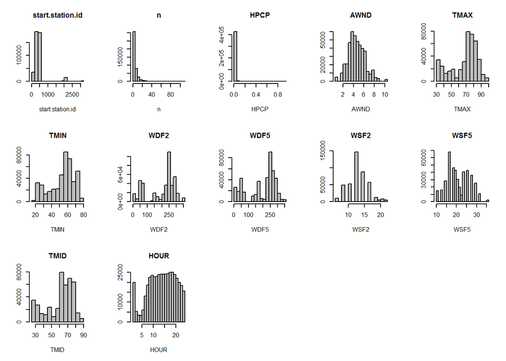

## Data transformation

We will perform Box-cox transformation on the following predictor variables: AWND, TMAX, TMIN, WDF2, WDF5, WSF2, WSF5, TMID. we will create a separate data frame to hold the transformed values and will have 2 data sets to chose from during modeling, one with raw data and one that has some of the predictors transformed.

Lets preview transformed predictors

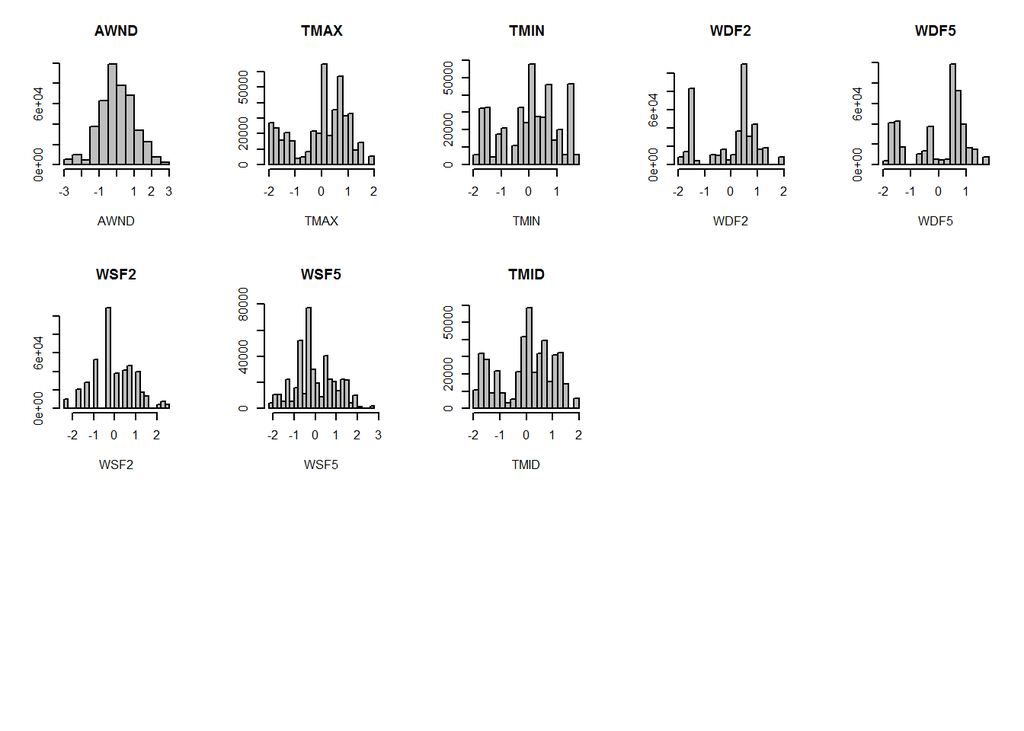

Looks like most of the predictors have benefited from transformation, some more then the other but overal there seems to be a positive change to the shape of the distribution.

## Correlation plot

Next we will create and review the correlation plot to see if we have heavy correlation in any of the predictor variables.

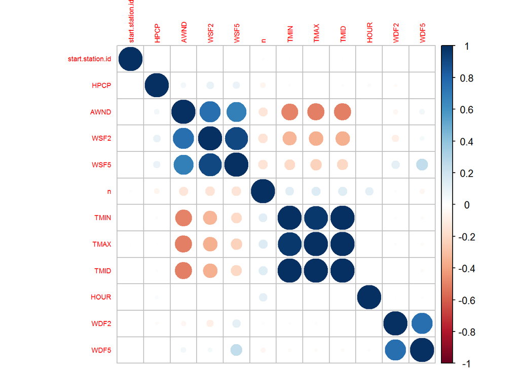

It appears there is a heavy correlation between TMIN,TMAX and TMD variables, also there is some correlation between WSF5 and WSF2 variables. We will make a not of these existing relationships and will make adjustments when creating our models if needed.

#### NOTE: you have 2 dataframes: data which contains non-transformed data and you have datanorm, which contains same data but with box-cox applied to some of the predictors.